# StatComp_hw1

凌浩东

10/3/2021

## 3.3

The inverse is
$$F^{-1}(x) = \frac{b}{(1 - y)^{\frac{1}{a}}}$$
.

Use the inverse transformation method to simulate a random sample from Pareto(2, 2) distribution:

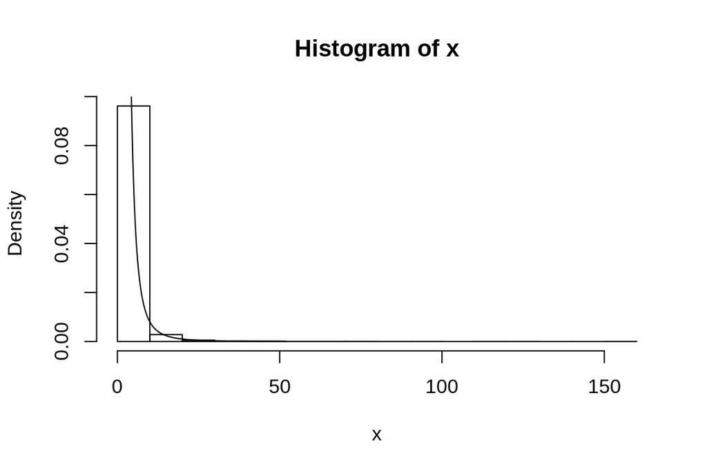

```r
library(ggplot2)
set.seed(42)

n <- 10000
u <- runif(n)
x <- 2 / sqrt(1 - u)
hist(x, probability = T)
y <- seq(2, 52, 0.01)
lines(y, 8 / y^3)
```

## 3.5

```r
rpmf <- function(n) {
  # return a random sample from the pmf
  # given by the question with sample size n
  u <- runif(n)
  x = integer(n)
  for (i in 1:n) {
    if (0.1 < u[i] & u[i] <= 0.3)
      x[i] = 1
    else if (0.3 < u[i] & u[i] <= 0.5)
      x[i] = 2
    else if (0.5 < u[i] & u[i] <= 0.7)
      x[i] = 3
    else if (0.7 < u[i] & u[i] <= 1)
      x[i] = 4
  }
  x
}

n <- 1000
x <- rpmf(n)
y <- sample(c(0:4), size = n, replace = T, prob = c(0.1,0.2,0.2,0.2,0.3))
round(rbind(c(0.1,0.2,0.2,0.2,0.3), table(x)/n, table(y)/n), 3)
```

```
##          0     1     2     3     4
## [1,] 0.100 0.200 0.200 0.200 0.300
## [2,] 0.105 0.183 0.198 0.206 0.308
## [3,] 0.103 0.207 0.188 0.199 0.303
```

## 3.6

In the discrete case,
$$P(accept|Y) = P(U<\frac{f(Y)}{cg(Y)}|Y) = \frac{f(Y)}{cg(Y)}$$
The last equality comes from U is uniform distributed and $\frac{f(t)}{cg(t)} \le 1$ for any t such that $f(t) \ge 0$.

The total probability of acceptance for ant iteration is
$$P(accept) = \sum_{y} P(accept|y) P(y) = \sum_y \frac{f(y)}{cg(y)}g(y) = \frac{1}{c}$$

Hence, the probability that the accept variants generated from Acceptance-rejection method equals to k is
$$P(k|accept) = \frac{P(accept|k)g(k)}{P(accept)} = \frac{\frac{f(k)}{cg(k)}g(k)}{\frac{1}{c}} = f(k)$$
Thus, in the discrete case, the distribution of the accept variants generated from Acceptance-rejection method is same to the target distribution.

In the continuous case,
$$P(accept|Y\le y) = \frac{\int_{-\infty}^{y}\frac{f(t)}{cg(t)}g(t)dt}{G(y)} = \frac{F(y)}{cG(y)}$$
$$\begin{align*}
P(accept) &= P\left(U \le \frac{f(Y)}{cg(Y)}\right) =
E\left[\mathbb{I}\left(U \le\frac{f(Y)}{cG(Y)}\right)\right]\\
&=E\left[E\left[\left. \mathbb{I}\left(U \le\frac{f(Y)}{cG(Y)}\right)\right|Y\right]\right]\\
&=E\left[P\left(\left. U \le\frac{f(Y)}{cG(Y)}\right|Y\right)\right]\\
&=E\left[\frac{f(Y)}{cg(Y)}\right]\\
&=\int\frac{f(y)}{cg(y)}g(y)dy\\
&= \frac{1}{c}
\end{align*}$$
$$P(Y\le k|accept) = \frac{P(accept|Y\le k)P(Y \le k)}{P(accept)} = \frac{\frac{F(y)}{cG(y)}G(y)}{\frac{1}{c}} = F(y)$$
Hence, the distribution of the accept variants generated from Acceptance-rejection method is same to the target distribution.

## 3.9

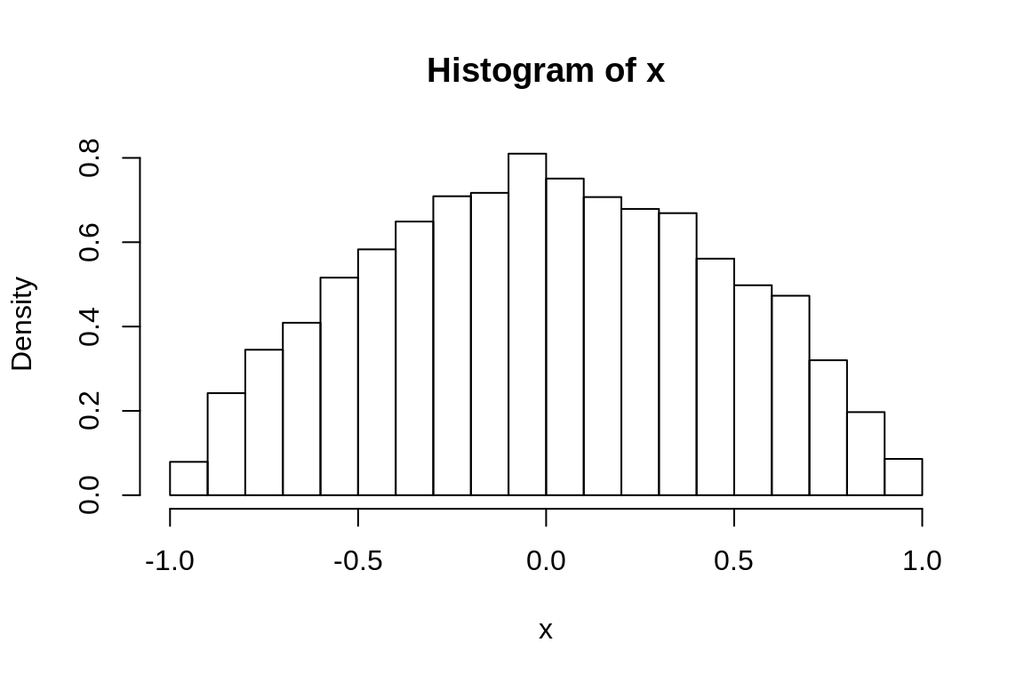

```r
rREK <- function(n) {
  u1 <- runif(n, -1, 1)
  u2 <- runif(n, -1, 1)
  u3 <- runif(n, -1, 1)
  x <- integer(n)
  for (i in 1:n) {
    if (abs(u3[i]) > abs(u2[i]) & abs(u3[i]) > abs(u1[i])) {
      x[i] <- u2[i]
    } else {
      x[i] <- u3[i]
    }
  }
  x
}

n <- 10000
x <- rREK(n)
hist(x, probability = T)
```

## 3.10

The essence of the algorithm is

- generate three random variables from standard uniform distribution.
- randomly choose one from the two with smaller value.
- negate it with probability $\frac{1}{2}$.

Suppose we choose X and $X \le t$. If the three absolute value of the random variables are all smaller that t, then the probability is
$$t^3$$
If there are only two variables smaller than t, the probability is
$$\tbinom{3}{2}t^2(1-t) = 3t^2(1-t)$$
If there are only one variables smaller that t, then this variable has $\frac{1}{2}$ chance to be X. Hence the probability of $X \le t$ is
$$\frac{1}{2}\binom{3}{1}t(1-t)^2 = \frac{3}{2}t(1-t)^2$$
Thus the probability of X smaller than t is
$$P(X \leq t) = t^3+3t^2(1-t)+\frac{3}{2}t(1-t)^2 = \frac{3}{2}t - \frac{1}{2}t^3$$
for $t \in [0,1]$.

## 3.14

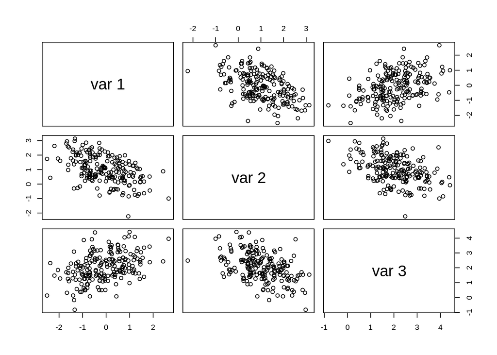

```r
mu <- c(0, 1, 2)
sigma <- matrix(c(1, -0.5, 0.5, -0.5, 1, -0.5, 0.5, -0.5, 1), nrow = 3, ncol = 3)
rmvn.Choleski <- function(n, mu, sigma) {
  d <- length(mu)
  Q <- chol(sigma)
  Z <- matrix(rnorm(n*d), nrow = n, ncol = d)
  X <- Z %*% Q + matrix(mu, n, d , byrow = T)
  X
}
X <- rmvn.Choleski(200, mu, sigma)
pairs(X)
```

## 5.2

```r
x <- seq(.1, 2.5, length = 10)
m <- 10000
cdf <- numeric(length(x))
for (i in 1:length(x)) {
  u <- runif(m, 0, x[i])
  g <- exp(- u^2/2)
  cdf[i] <- x[i] * mean(g) / sqrt(2*pi) + 0.5
}
Phi <- pnorm(x)
print(round(rbind(x, cdf, Phi), 3))
```

```
##     [,1]  [,2]  [,3]  [,4]  [,5]  [,6]  [,7]  [,8]  [,9] [,10]
## x   0.10 0.367 0.633 0.900 1.167 1.433 1.700 1.967 2.233 2.500
## cdf 0.54 0.643 0.737 0.816 0.879 0.923 0.954 0.974 0.986 1.000
## Phi 0.54 0.643 0.737 0.816 0.878 0.924 0.955 0.975 0.987 0.994
```

```r
x <- 2
m <- 10000
u <- runif(m, 0, x)
g <- x * exp(- u^2/2) / sqrt(2 * pi)
v <- mean((g - mean(g))^2) / m
cdf <- mean(g)
c(cdf, v)
```

```
## [1] 4.775627e-01 5.364028e-06
```

```r
c(cdf - 1.96 * sqrt(v), cdf + 1.96 * sqrt(v))
```

```
## [1] 0.4730232 0.4821021
```

## 5.3

```r
x <- 0.5
m <- 10000
u <- runif(m, 0, x)
g <- x * exp(-u)
cdf <- mean(g)
v <- mean((g - mean(g))^2) / m
c(cdf, v)
```

```
## [1] 3.935316e-01 3.154967e-07
```

```r
z <- rexp(m)
z.g <- (z < x)
z.v <- mean((z.g - mean(z.g))^2) / m
z.cdf <- mean(z.g)
c(z.cdf, z.v)
```

```
## [1] 3.866000e-01 2.371404e-05
```

$\hat{\theta}$ is smaller. Because in the case of sampling from exponential distribution, there is a big probability of get very close to 0, which makes the computer harder to be precise.